# Assignment 2

Jennifer Horowitz

9/15/2020

## Setup

```r
library(tidyverse)
```

```r
baseball<-read_csv('baseballstats.csv')
```

## Variables Chosen

I chose variables:

1. nameFirst: First name of the player
2. nameLast: Last name of the player
3. birthDate: Date player was born
4. birthCountry: Country the player was born
5. weight: Weight of the player (in pounds)
6. height: Height of the player (in inches)
7. bats: If the player bats right or left handed
8. batting_average: Batting average of the player. Calculated by their number of hits divided by at bats
9. slugging_average: Average slugging percentage. Total number of bases dived by at bats.
10. gdp_per_capita: GDP from 1996, normalized to 2019 USD
11. Continent: This column was newly created in order to simplify my analysis.

## Distribution of Continuous Variables

### Descriptive statistics

First I calculated summary statistics.

```r
weight_summary <-  summary(baseball$weight)
weight_sd <- sd(baseball$weight, na.rm = TRUE)
weight_pop_mean_int <- t.test(baseball$weight)
height_summary <-  summary(baseball$height)
height_sd <- sd(baseball$height, na.rm = TRUE)
height_pop_mean_int <- t.test(baseball$height)
ba_summary <-  summary(baseball$batting_average)
ba_sd <- sd(baseball$batting_average, na.rm = TRUE)
ba_pop_mean_int <- t.test(baseball$batting_average)
slugging_average_summary <-  summary(baseball$slugging_average)
slugging_average_sd <- sd(baseball$slugging_average, na.rm = TRUE)
slugging_average_pop_mean_int <- t.test(baseball$slugging_average)
gdp_per_capita_summary <-  summary(baseball$gdp_per_capita)
gdp_per_capita_sd <- sd(baseball$gdp_per_capita, na.rm = TRUE)
gdp_per_capita_pop_mean_int <- t.test(baseball$gdp_per_capita)
```

And display them in a formatted table:

```r
summary_table <- tibble(
  Statistic = c("Sample mean",
                "Median",
                "Standard deviation",
                "Interquartile range",
                "Population mean (95% confidence)"),
  `Median weight (pounds)` = c(prettyNum(weight_summary["Mean"], digits=3),
                           weight_summary["Median"],
                           prettyNum(weight_sd, digits = 3),
                           paste(weight_summary["1st Qu."],"to",
                                 weight_summary["3rd Qu."]),
                           paste(prettyNum(weight_pop_mean_int$conf.int[1],
                                           digits=3), "to",
                                 prettyNum(weight_pop_mean_int$conf.int[2],
                                               digits=3))),
  `Height (inches)` = c(prettyNum(height_summary["Mean"],digits=3),
                           height_summary["Median"],
                          prettyNum(height_sd, digits=3),
                           paste(height_summary["1st Qu."], "to",
                                 height_summary["3rd Qu."]),
                           paste(prettyNum(height_pop_mean_int$conf.int[1],
                                           digits=3), "to",
                                 prettyNum(height_pop_mean_int$conf.int[2],
                                           digits=3))),

`Batting Average` = c(prettyNum(ba_summary["Mean"], digits=3),
                           ba_summary["Median"],
                           prettyNum(ba_sd, digits = 3),
                           paste(ba_summary["1st Qu."],"to",
                                 ba_summary["3rd Qu."]),
                           paste(prettyNum(ba_pop_mean_int$conf.int[1],
                                           digits=3), "to",
                                 prettyNum(ba_pop_mean_int$conf.int[2],
                                               digits=3))),

`Slugging average` = c(prettyNum(slugging_average_summary["Mean"], digits=3),
                          slugging_average_summary["Median"],
                           prettyNum(slugging_average_sd, digits = 3),
                           paste(slugging_average_summary["1st Qu."],"to",
                                 slugging_average_summary["3rd Qu."]),
                           paste(prettyNum(slugging_average_pop_mean_int$conf.int[1],
                                           digits=3), "to",
                                 prettyNum(slugging_average_pop_mean_int$conf.int[2],
                                               digits=3))),

`GDP Per Capita` = c(prettyNum(gdp_per_capita_summary["Mean"], digits=3),
                           gdp_per_capita_summary["Median"],
                           prettyNum(gdp_per_capita_sd, digits = 3),
                           paste(gdp_per_capita_summary["1st Qu."],"to",
                                gdp_per_capita_summary["3rd Qu."]),
                           paste(prettyNum(gdp_per_capita_pop_mean_int$conf.int[1],
                                           digits=3), "to",
                                 prettyNum(gdp_per_capita_pop_mean_int$conf.int[2],
                                               digits=3))))


knitr::kable(summary_table,
             caption = "Baseball Statistics")
```

Baseball Statistics

| Statistic | Median weight (pounds) | Height (inches) | Batting Average | Slugging average | GDP Per Capita |
| --- | --- | --- | --- | --- | --- |
| Sample mean | 191 | 73.2 | 0.215 | 0.0158 | 28927 |
| Median | 190 | 73 | 0.241610738255034 | 0.00198347107438017 | 29967.7127181749 |
| Standard deviation | 18.3 | 2.23 | 0.124 | 0.0791 | 5069 |
| Interquartile range | 180 to 200 | 72 to 75 | 0.155555555555556 to 0.284457478005865 | 0.000904260393809549 to 0.00541683181397807 | 29967.7127181749 to 29967.7127181749 |
| Population mean (95% confidence) | 190 to 193 | 73.1 to 73.4 | 0.206 to 0.224 | 0.0101 to 0.0214 | 28565 to 29290 |

### Histograms

Now, I’ll create histogram for each of these five.

#### Weight Histogram Distribution

The majority of baseball players are less than 200 lbs. It is right skewed.

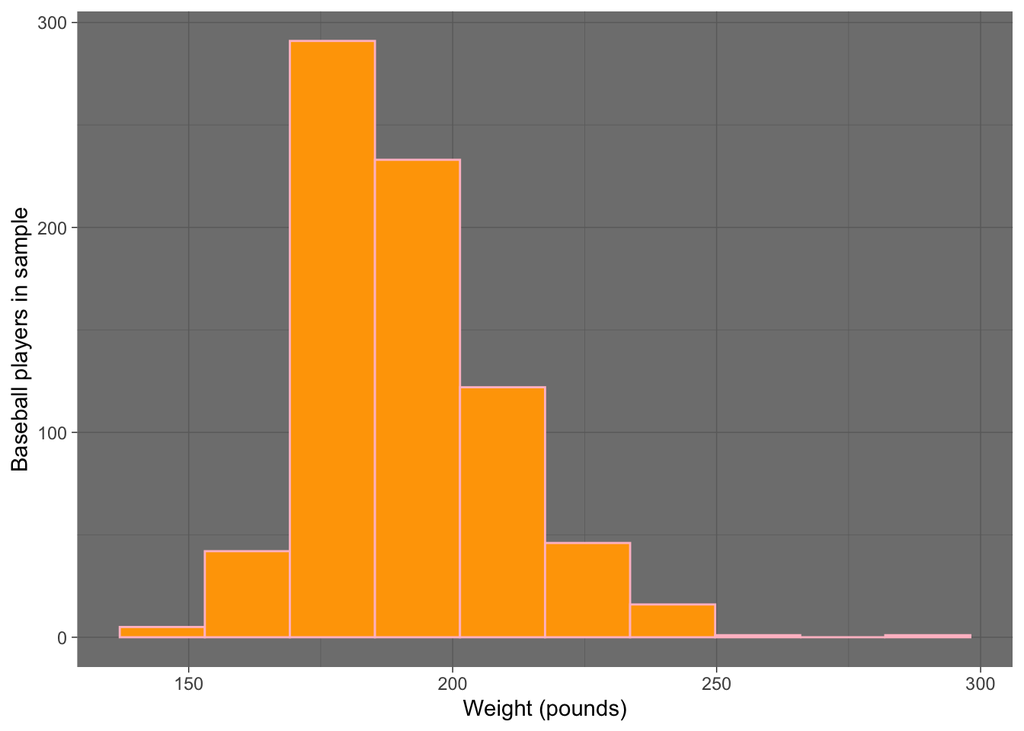

```r
ggplot(baseball, aes(x = weight)) +
  geom_histogram(color = "pink",bins=10, fill="orange") +
  theme_dark() +
  scale_x_continuous(name = "Weight (pounds)") +
  scale_y_continuous(name = "Baseball players in sample")
```

#### Height Histogram Distribution

The majority of baseball players are taller than 6ft. It is an approximately normal distribution.

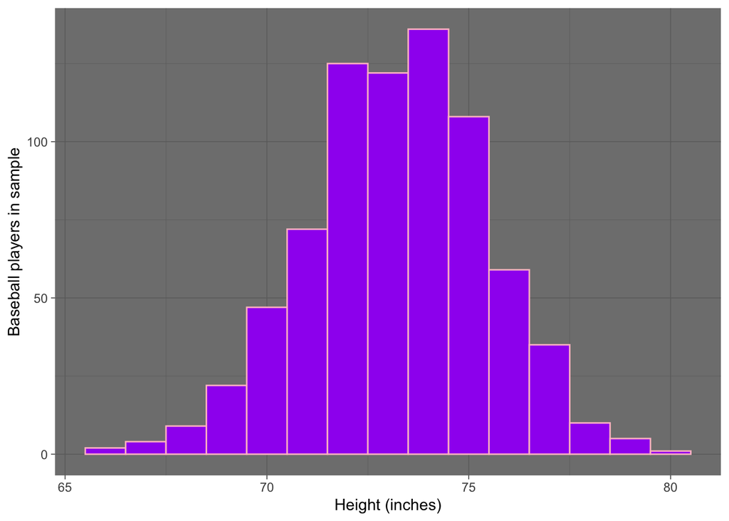

```r
ggplot(baseball, aes(x = height)) +
  geom_histogram(color = "pink", binwidth = 1,bins=10, fill="purple") +
  theme_dark() +
  scale_x_continuous(name = "Height (inches)") +
  scale_y_continuous(name = "Baseball players in sample")
```

#### Batting Average Histogram

The batting average centered between .250/.260. There appeared to be some outliers as well because some people had a couple “at-bats” or one hit.

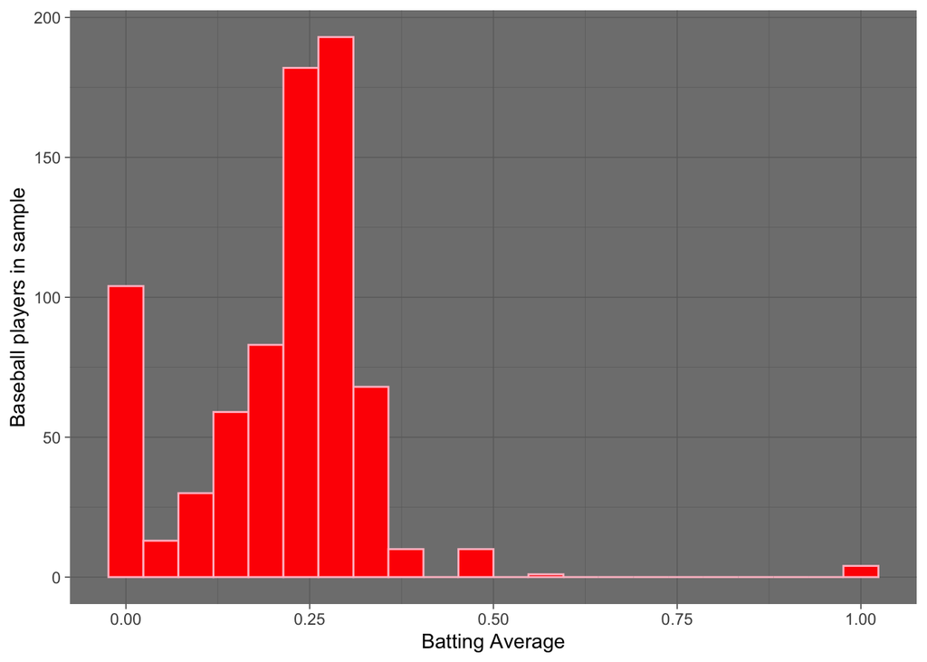

```r
ggplot(baseball, aes(x = batting_average)) +
  geom_histogram(color = "pink",bins=22, fill="red") +
  theme_dark() +
  scale_x_continuous(name = "Batting Average") +
  scale_y_continuous(name = "Baseball players in sample")
```

#### Slugging Average Histogram

On average playeres had an average of less than .3.

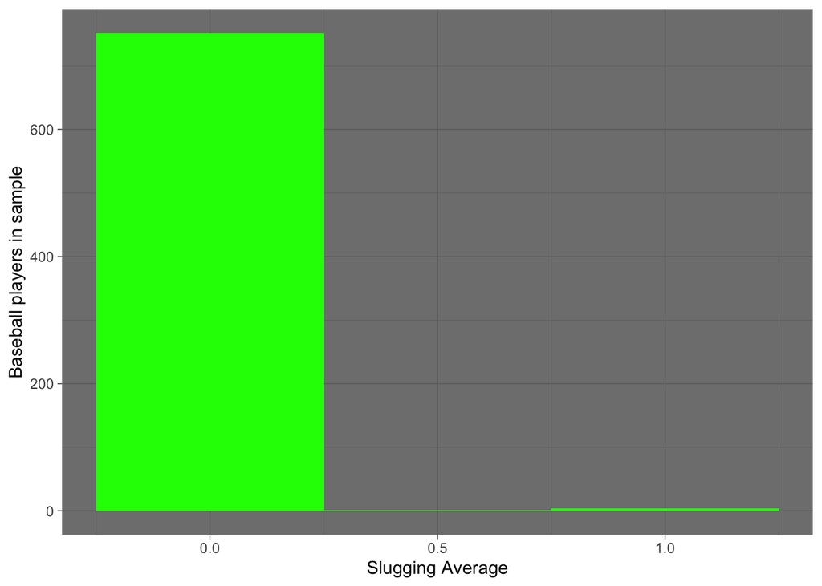

```r
ggplot(baseball, aes(x = slugging_average)) +
  geom_histogram( bins=3, fill="green") +
  theme_dark() +
  scale_x_continuous(name = "Slugging Average") +
  scale_y_continuous(name = "Baseball players in sample")
```

#### GDP Per Capita Histogram

The vast majority of players come from countries with a GDP per capita of 30000.

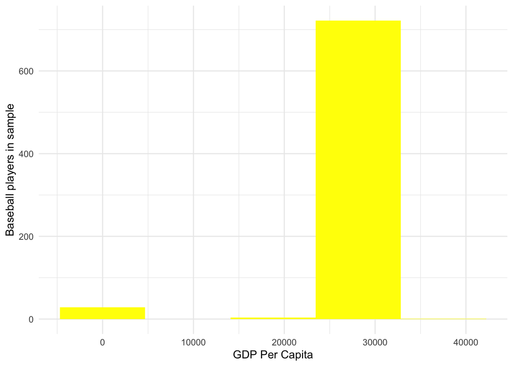

```r
ggplot(baseball, aes(x = gdp_per_capita)) +
  geom_histogram( bins=5, fill="yellow") +
  theme_minimal() +
  scale_x_continuous(name = "GDP Per Capita") +
  scale_y_continuous(name = "Baseball players in sample")
```

## Distribution of Categorical Variables

I’ll show two tables, one showing the proportions of each category for each of my categorical variables. It should be noted that the countries column was broken up further into continents.

```r
baseball<-baseball %>%
  mutate(
    continent = case_when (
      birthCountry =="United States"~"North America",
      birthCountry =="Jamaica"~"North America",
      birthCountry =="Nicaragua"~"Central America",
      birthCountry =="Mexico"~"Central America",
      birthCountry =="Panama"~"Central America",
      birthCountry =="Cuba"~"Central America",
      birthCountry =="Curacao"~"South America",
      birthCountry =="Colombia"~"South America",
      TRUE ~ "other"
    )
  )
```

### Test Statistic Values

```r
northamerica <- t.test (baseball$continent == "North America")
centralamerica <- t.test (baseball$continent == "Central America")
southamerica <- t.test (baseball$continent == "South America")
other <- t.test (baseball$continent == "other")
```

### Continent Proportions

```r
tibble(`Majority Country` = c("North America",
                                  "South America",
                                  "Central America",
                                  "Other"),
                 `Sample proportion` = c(paste(prettyNum(northamerica$estimate*100,
                                                         digits = 3), "%"),
                                         paste(prettyNum(southamerica$estimate*100,
                                                         digits = 3), "%"),
                                         paste(prettyNum(centralamerica$estimate*100,
                                                         digits = 3), "%"),
                                         paste(prettyNum(other$estimate*100,
                                                         digits = 3), "%")),
                 `95-percent confidence interval` = c(
                   paste(prettyNum(northamerica$conf.int[1]*100, digits=3),
                         "% to ",
                         prettyNum(northamerica$conf.int[2]*100, digits=3),
                         "%", sep=""),
                   paste(prettyNum(southamerica$conf.int[1]*100, digits=3),
                         "% to ",
                         prettyNum(southamerica$conf.int[2]*100, digits=3),
                         "%", sep=""),
                   paste(prettyNum(centralamerica$conf.int[1]*100, digits=3),
                         "% to ",
                         prettyNum(centralamerica$conf.int[2]*100, digits=3),
                         "%", sep=""),
                   paste(prettyNum(other$conf.int[1]*100, digits=3),
                         "% to ",
                         prettyNum(other$conf.int[2]*100, digits=3),
                         "%", sep="")))
```

```
## # A tibble: 4 x 3
##   `Majority Country` `Sample proportion` `95-percent confidence interval`
##   <chr>              <chr>               <chr>
## 1 North America      94.7 %              93.1% to 96.3%
## 2 South America      0.396 %             -0.0523% to 0.845%
## 3 Central America    3.3 %               2.03% to 4.58%
## 4 Other              1.59 %              0.693% to 2.48%
```

### Batting: Right, Left, or Both

The majority of people bat right.

```r
batsright <- t.test(baseball$bats=="R")
batsleft <- t.test(baseball$bats=="L")
batsboth <- t.test(baseball$bats=="B")
```

```r
tibble(`Majority Batting Stance` = c("Bats Right",
                                  "Bats Left",
                                  "Bats Right and Bats Left"),
                 `Sample proportion` = c(paste(prettyNum(batsright$estimate*100,
                                                         digits = 3), "%"),
                                         paste(prettyNum(batsleft$estimate*100,
                                                         digits = 3), "%"),
                                         paste(prettyNum(batsboth$estimate*100,
                                                         digits = 3), "%")),
                 `95-percent confidence interval` = c(
                   paste(prettyNum(batsright$conf.int[1]*100, digits=3),
                         "% to ",
                         prettyNum(batsright$conf.int[2]*100, digits=3),
                         "%", sep=""),
                  paste(prettyNum(batsleft$conf.int[1]*100, digits=3),
                         "% to ",
                         prettyNum(batsleft$conf.int[2]*100, digits=3),
                         "%", sep=""),
                   paste(prettyNum(batsboth$conf.int[1]*100, digits=3),
                         "% to ",
                         prettyNum(batsboth$conf.int[2]*100, digits=3),
                         "%", sep="")))
```

```
## # A tibble: 3 x 3
##   `Majority Batting Stance` `Sample proportion` `95-percent confidence interval`
##   <chr>                     <chr>               <chr>
## 1 Bats Right                62.1 %              58.6% to 65.6%
## 2 Bats Left                 26.4 %              23.3% to 29.6%
## 3 Bats Right and Bats Left  11.5 %              9.22% to 13.8%
```